# Solutions for Mini-project 6 on Value Courier, PSYC 2300, Human Memory

# Problem 1 - Lag-CRP with Time Bins

To measure the influence of absolute time on the dynamics of recall, plot the conditional response probability as a function of lag (the lag-CRP) in terms of time bins instead of serial or list positions as you completed previously. Compute the CRP for lags -2, -1, +1, and +2. CRPs for the other lags can be found in the spreadsheet 'CRPs'. Compare this result to what you have previously seen in lag-CRP curves for the free recall word-list task.

```
Lag-CRP for Time Bins:
CRP for lag -2: 0.11621
CRP for lag -1: 0.10942
CRP for lag 1: 0.14622
CRP for lag 2: 0.094737
```

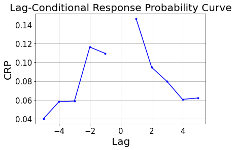

## Problem 2:

Come up with a method for illustrating people’s tendency to learn the spatial layout of the environment and improve their navigation over the six successive delivery days. If a subject knew the layout of the virtual environment well, how would you expect their task performance to differ from a subject who was unfamiliar with the environment? Describe your method, show the results, and provide some interpretation.

Solution: Results will vary. Two ideas:

1. Time between deliveries will decrease on average as subjects become more familiar with the town layout
2. Time between deliveries normalized by Euclidean distance between stores will decrease as well and (imperfectly) account for the intrinsic difficulty of a delivery.

Students needed to propose a valid method, show results, and evaluate the outcomes: do subjects show improvement over trials/delivery days?

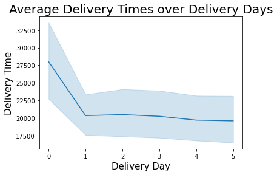

We do see improvement in subject delivery times after the first delivery day with this rough method of averaging delivery times over subjects for separate delivery days. Subject performance as measured by this method then saturates after the first delivery day. Better methods would control for difficulty of delivery by controlling for delivery distance or better yet, minimum path length between stores.

## Problem 3:

Come up with a method of illustrating people’s tendency to organize their recalls based on the distances between the delivered objects. Can you think of a method akin to the lag-CRP for free recall, but using spatial distance or using the shortest path that people could have taken between stores? Does this tendency, if present, depend on how well people knew the layout of the environment? You do not need to implement your proposed analyses in these data but make sure your description is clear and well defined. You further do not need to restrict yourself to the data types given to you in this assignment and can assume that any information relevant to the task (e.g. the coordinates and viewpoints of the subject in the town during navigation) are recorded every 100 ms and available to you.

Solution: Results will vary.

1. Method:
   - One idea for a method: Compute the percentile-binned spatial distances between the stores where items were presented in recall order (so for a transition between item i and item j, compute the distance between the store where item i was presented and the store where item j was presented). Then compute the CRP curves based on spatial distance bins instead of lags of serial positions in recall order as in the standard lag-CRP for free recall word-list experiments.
   - Students need to propose a method that in some way addresses the organization of recall based on spatial distances.
2. Does the method depend on spatial familiarity?
   - Students need to answer the question and give some kind of rationale.